# R Lab 11 Key

## Set-up

```r
library(ggplot2) # for graphing
library(viridis) # color palettes
library(MetBrewer) # color palettes
library(tidyverse) # for data cleaning
library(psych) # tests
library(effectsize)
library(car)
```

## Cholesterol data description

A study tested whether cholesterol was reduced after using a certain brand of margarine as part of a low fat, low cholesterol diet. The subjects consumed on average 2.31g of the active ingredient, stanol easter, a day. This data set contains information on 18 people using margarine to reduce cholesterol over three time points.

```r
chol <- read.csv("../Data/Cholesterol_R.csv")
glimpse(chol)
```

```
## Rows: 18
## Columns: 5
## $ ID          <int> 1, 2, 3, 4, 5, 6, 7, 8, 9, 10, 11, 12, 13, 14, 15, 16, 17,…
## $ Before      <dbl> 6.42, 6.76, 6.56, 4.80, 8.43, 7.49, 8.05, 5.05, 5.77, 3.91…
## $ After4weeks <dbl> 5.83, 6.20, 5.83, 4.27, 7.71, 7.12, 7.25, 4.63, 5.31, 3.70…
## $ After8weeks <dbl> 5.75, 6.13, 5.71, 4.15, 7.67, 7.05, 7.10, 4.67, 5.33, 3.66…
## $ Margarine   <chr> "B", "A", "B", "A", "B", "A", "B", "A", "B", "A", "B", "B"…
```

Below I am creating two new variables: `loss.4` and `loss.8`. They represent the amount their cholesterol lowered after that respective time period.

```r
chol$loss.4 <- chol$Before - chol$After4weeks

chol$loss.8 <- chol$Before - chol$After8weeks
```

### EXERCISE 1: One-Way ANOVA 4 Weeks

Use the `aov()` function to test if there is a difference in `loss.4` based on which `Margarine` they consumed. Remember, you will need to assign the `aov` to an object name of your choice (example: `mod.4.weeks`). Then, to see the output, run the `summary()` function on the object name.

```r
mod.4.weeks <- aov(loss.4 ~ Margarine, chol)
summary(mod.4.weeks)
```

```
##             Df Sum Sq Mean Sq F value Pr(>F)
## Margarine    1 0.1168 0.11681   6.343 0.0228 *
## Residuals   16 0.2946 0.01841
## ---
## Signif. codes:  0 '***' 0.001 '**' 0.01 '*' 0.05 '.' 0.1 ' ' 1
```

### EXERCISE 2: Interpret One-Way ANOVA 4 Weeks

Interpret the aov output from exercise 1.

### EXERCISE 3: Tukey’s 4 Weeks

Use the `TukeyHSD` function to run the group comparison.

```r
TukeyHSD(mod.4.weeks)
```

```
##   Tukey multiple comparisons of means
##     95% family-wise confidence level
##
## Fit: aov(formula = loss.4 ~ Margarine, data = chol)
##
## $Margarine
##          diff        lwr       upr     p adj
## B-A 0.1611111 0.02550385 0.2967184 0.0228039
```

### EXERCISE 4: Effect Size 4 Weeks

Use the `eta_squared()` function to get the effect size for your aov object. Then, interpret the effect size.

```r
eta_squared(mod.4.weeks)
```

```
## For one-way between subjects designs, partial eta squared is equivalent to eta squared.
## Returning eta squared.
```

```
## # Effect Size for ANOVA
##
## Parameter | Eta2 |       95% CI
## -------------------------------
## Margarine | 0.28 | [0.03, 1.00]
##
## - One-sided CIs: upper bound fixed at (1).
```

### EXERCISE 5: Plot 4 Weeks

Use `stat_summary()` in a `ggplot` to show the Margarine group differences. Inside of `stat_summary()`, set `fun = "mean"`, `geom = "bar"`, and `position = "dodge"`. Lastly, add a theme.

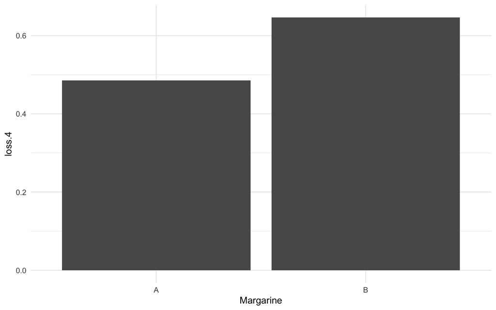

```r
ggplot(chol, aes(x = Margarine, y = loss.4)) +
  stat_summary(fun = "mean", geom = "bar", position = "dodge") +
  theme_minimal()
```

### EXERCISE 6: One-Way ANOVA 8 Weeks

Use the `aov()` function to test if there is a difference in `loss.8` based on which `Margarine` they consumed. Remember, you will need to assign the `aov` to an object name of your choice (example: `mod.8.weeks`). Then, to see the output, run the `summary()` function on the object name.

```r
mod.8.weeks <- aov(loss.8 ~ Margarine, chol)
summary(mod.8.weeks)
```

```
##             Df Sum Sq Mean Sq F value Pr(>F)
## Margarine    1 0.1217 0.12169   4.635 0.0469 *
## Residuals   16 0.4201 0.02626
## ---
## Signif. codes:  0 '***' 0.001 '**' 0.01 '*' 0.05 '.' 0.1 ' ' 1
```

### EXERCISE 7: Interpret One-Way ANOVA 8 Weeks

Interpret the aov output from exercise 6.

Use the `TukeyHSD` function to run the group comparison.

```r
TukeyHSD(mod.8.weeks)
```

```
##   Tukey multiple comparisons of means
##     95% family-wise confidence level
##
## Fit: aov(formula = loss.8 ~ Margarine, data = chol)
##
## $Margarine
##          diff         lwr      upr     p adj
## B-A 0.1644444 0.002516874 0.326372 0.0469334
```

### EXERCISE 9: Effect Size 8 Weeks

Use the `eta_squared()` function to get the effect size for your aov object. Then, interpret the effect size.

```r
eta_squared(mod.8.weeks)
```

```
## For one-way between subjects designs, partial eta squared is equivalent to eta squared.
## Returning eta squared.
```

```
## # Effect Size for ANOVA
##
## Parameter | Eta2 |       95% CI
## -------------------------------
## Margarine | 0.22 | [0.00, 1.00]
##
## - One-sided CIs: upper bound fixed at (1).
```

### EXERCISE 10: Plot 8 Weeks

Use `stat_summary()` in a `ggplot` to show the Margarine group differences. Inside of `stat_summary()`, set `fun = "mean"`, `geom = "bar"`, and `position = "dodge"`. Lastly, add a theme.

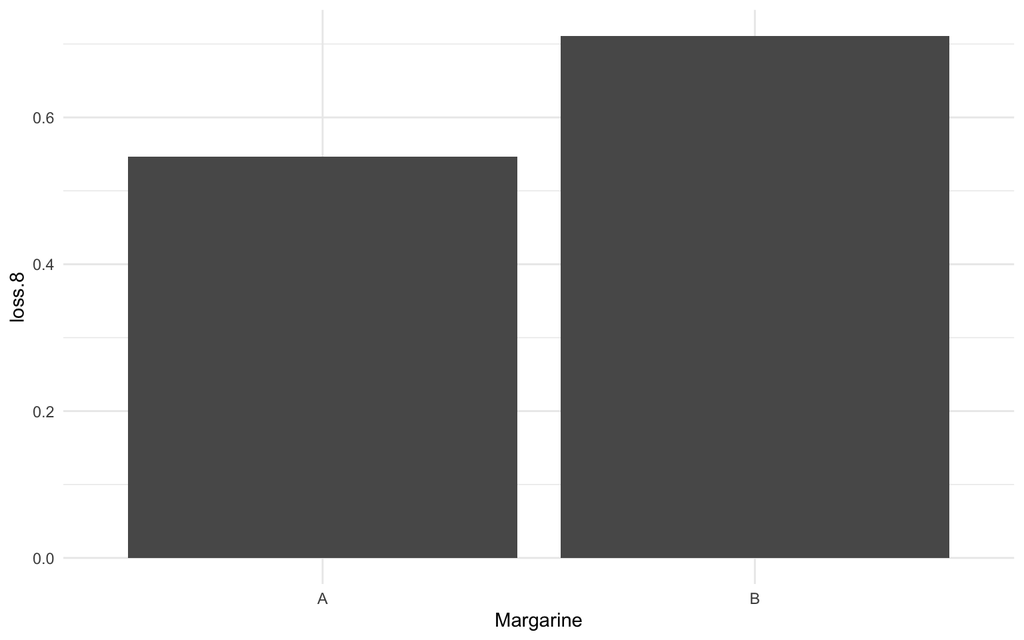

```r
ggplot(chol, aes(x = Margarine, y = loss.8)) +
  stat_summary(fun = "mean", geom = "bar", position = "dodge") +
  theme_minimal()
```

## PalmerPenguins

Data were collected and made available by Dr. Kristen Gorman and the Palmer Station, Antarctica LTER, a member of the Long Term Ecological Research Network. The dataset contains data for 344 penguins. There are 3 different species of penguins in this dataset, collected from 3 islands in the Palmer Archipelago, Antarctica.

```r
library(palmerpenguins)
glimpse(penguins)
```

```
## Rows: 344
## Columns: 8
## $ species           <fct> Adelie, Adelie, Adelie, Adelie, Adelie, Adelie, Adel…
## $ island            <fct> Torgersen, Torgersen, Torgersen, Torgersen, Torgerse…
## $ bill_length_mm    <dbl> 39.1, 39.5, 40.3, NA, 36.7, 39.3, 38.9, 39.2, 34.1, …
## $ bill_depth_mm     <dbl> 18.7, 17.4, 18.0, NA, 19.3, 20.6, 17.8, 19.6, 18.1, …
## $ flipper_length_mm <int> 181, 186, 195, NA, 193, 190, 181, 195, 193, 190, 186…
## $ body_mass_g       <int> 3750, 3800, 3250, NA, 3450, 3650, 3625, 4675, 3475, …
## $ sex               <fct> male, female, female, NA, female, male, female, male…
## $ year              <int> 2007, 2007, 2007, 2007, 2007, 2007, 2007, 2007, 2007…
```

### EXERCISE 11: Two-Way ANOVA Penguins

Use the `aov()` function to test if there is a difference in `body_mass_g` based on the interaction of penguin `sex` and penguin `species`. To run the interaction, you will use an asterik `*` to separate the two variable names.

Remember, you will need to assign the `aov` to an object name of your choice (example: `mod.penguins`). Then, to see the output, run the `summary()` function on the object name.

```r
mod.penguins <- aov(body_mass_g ~ sex*species, penguins)
summary(mod.penguins)
```

```
##              Df    Sum Sq  Mean Sq F value   Pr(>F)
## sex           1  38878897 38878897 406.145  < 2e-16 ***
## species       2 143401584 71700792 749.016  < 2e-16 ***
## sex:species   2   1676557   838278   8.757 0.000197 ***
## Residuals   327  31302628    95727
## ---
## Signif. codes:  0 '***' 0.001 '**' 0.01 '*' 0.05 '.' 0.1 ' ' 1
## 11 observations deleted due to missingness
```

### EXERCISE 13: Tukey’s

Use the `TukeyHSD` function to run the group comparison. Look at the `p adj` column and note down which comparisons are significantly different.

```r
TukeyHSD(mod.penguins)
```

```
##   Tukey multiple comparisons of means
##     95% family-wise confidence level
##
## Fit: aov(formula = body_mass_g ~ sex * species, data = penguins)
##
## $sex
##                 diff      lwr      upr p adj
## male-female 683.4118 616.7003 750.1233     0
##
## $species
##                        diff       lwr       upr     p adj
## Chinstrap-Adelie   26.92385  -80.0258  133.8735 0.8241288
## Gentoo-Adelie    1377.65816 1287.6926 1467.6237 0.0000000
## Gentoo-Chinstrap 1350.73431 1239.9964 1461.4722 0.0000000
##
## $`sex:species`
##                                      diff       lwr       upr     p adj
## male:Adelie-female:Adelie        674.6575  527.8486  821.4664 0.0000000
## female:Chinstrap-female:Adelie   158.3703  -25.7874  342.5279 0.1376213
## male:Chinstrap-female:Adelie     570.1350  385.9773  754.2926 0.0000000
## female:Gentoo-female:Adelie     1310.9058 1154.8934 1466.9181 0.0000000
## male:Gentoo-female:Adelie       2116.0004 1962.1408 2269.8601 0.0000000
## female:Chinstrap-male:Adelie    -516.2873 -700.4449 -332.1296 0.0000000
## male:Chinstrap-male:Adelie      -104.5226 -288.6802   79.6351 0.5812048
## female:Gentoo-male:Adelie        636.2482  480.2359  792.2606 0.0000000
## male:Gentoo-male:Adelie         1441.3429 1287.4832 1595.2026 0.0000000
## male:Chinstrap-female:Chinstrap  411.7647  196.6479  626.8815 0.0000012
## female:Gentoo-female:Chinstrap  1152.5355  960.9603 1344.1107 0.0000000
## male:Gentoo-female:Chinstrap    1957.6302 1767.8040 2147.4564 0.0000000
## female:Gentoo-male:Chinstrap     740.7708  549.1956  932.3460 0.0000000
## male:Gentoo-male:Chinstrap      1545.8655 1356.0392 1735.6917 0.0000000
## male:Gentoo-female:Gentoo        805.0947  642.4300  967.7594 0.0000000
```

### EXERCISE 14: Effect Sizes

Use the `eta_squared()` function to get the effect size for your aov object. Then, interpret the effect sizes.

```r
eta_squared(mod.penguins)
```

```
## # Effect Size for ANOVA (Type I)
##
## Parameter   | Eta2 (partial) |       95% CI
## -------------------------------------------
## sex         |           0.55 | [0.50, 1.00]
## species     |           0.82 | [0.80, 1.00]
## sex:species |           0.05 | [0.02, 1.00]
##
## - One-sided CIs: upper bound fixed at (1).
```

### EXERCISE 15: Plotting Penguins

Use `stat_summary()` in a `ggplot` to show the penguin `sex` and `species` group differences on `body_mass_g`. Inside of `stat_summary()`, set `fun = "mean"`, `geom = "bar"`, and `position = "dodge"`. Lastly, clean up the labels and add a theme.

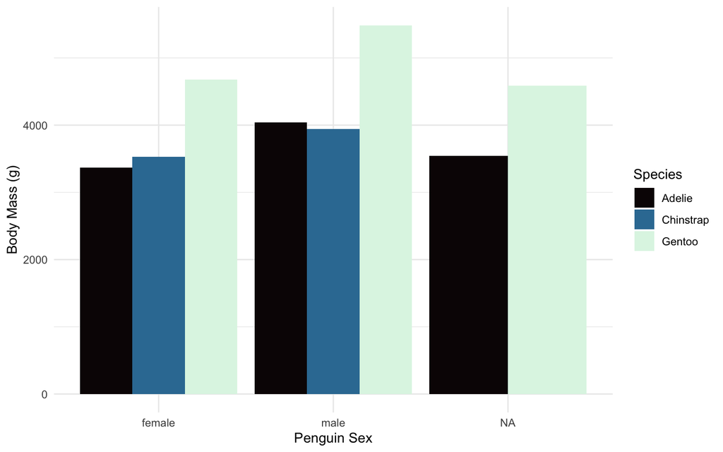

```r
ggplot(penguins, aes(x = sex, y = body_mass_g, fill = species)) +
  stat_summary(fun = "mean", geom = "bar", position = "dodge") +
  theme_minimal() +
  scale_fill_viridis_d(option = "mako") +
  labs(x = "Penguin Sex", y = "Body Mass (g)", fill = "Species")
```